# Chapter 7: Survey Sampling and Inference

COR 142 C

Author

Dr. Kao

## Introduction to Surveys

**NoteSurvey Terminology**

- A **population** is a group of objects or people we wish to study.
- A **parameter** is a numerical value that characterizes some aspect of the population.
- A **census** is a survey which measures **every member** of the population.
- A **sample** is a sub-collection of objects or people taken from the population of interest.
- A **statistic** is a numerical characteristic of the sampled data; it is sometimes called an **estimator**, and the numerical results are called the **estimates**.

**TipExample 7.1.1.**

**Question**

Data is gathered on the heights of all NBA basketball players. The mean of the data is calculated.

1. The _________ is all NBA players.
2. The _________ is the mean height of all NBA players.

**Answer**

1. The **population** is all NBA players.
2. The **parameter** is the mean height of all NBA players.

**TipExample 7.1.2.**

**Question**

A researcher is interested in studying the heights of American women. She takes a random sample of 1,500 American women and finds the mean height of the sample is 63.6 inches.

1. The _________ is the 1,500 American surveyed.
2. The _________ is the sample mean of 63.6 inches. The researcher may _________ that the average American woman is 63.6 inches tall.

**Answer**

1. The **sample** is the 1,500 American surveyed.
2. The **statistic** is the sample mean of 63.6 inches. The researcher may **estimate** that the average American woman is 63.6 inches tall.

**NoteStatistical Inference**

- **Statistical inference** is the science of drawing conclusions about a population based on observing characteristics of samples.
- Statistical inference involves uncertainty because the entire population is not being measured.
- An important component of statistical inference is **measuring the uncertainty**.

**NoteStatistics vs. Parameters**

**NoteNotation**

In general, Greek letters are used to represent population parameters, whereas Latin letters are used to represent statistics.

| Statistics (based on sample data) | Symbol | Parameters (typically unknown) | Symbol |
| --- | --- | --- | --- |
| Sample Mean | $\overline{x}$ | Population Mean | $\mu$ |
| Sample Standard Deviation | $s$ | Population Standard Deviation | $\sigma$ |
| Sample Variance | $s^2$ | Population Variance | $\sigma^2$ |
| Sample Proportion | $\hat{p}$ | Population Proportion | $p$ |

**TipExample 7.1.3.**

**Question**

The mean GPA of all 5,000 students at Uneeda College is 2.78. A sample of 50 GPAs from this college has a mean of 2.93.

1. What is the population?
2. What is the sample?
3. What value is the parameter? What symbol do we use to represent this value?
4. What value is the statistic? What symbol do we use to represent this value?

**Answer**

a. The population is all 5,000 students at Uneeda College.  
b. The sample consists of the 50 students whose GPAs were recorded.  
c. The parameter is the mean GPA of 2.78; we write $\mu = 2.78$.  
d. The statistic is the mean GPA of 2.93; we write $\bar{x} = 2.93$.

**NoteBias**

A survey method is **biased** if it has a tendency to produce an inaccurate or untrue value. There are three common types of bias:

- **Measurement** bias
- **Sampling** bias
- **Estimator bias**—the use of an estimator that is biased

**NoteMeasurement Bias**

1. Results from asking questions that do not **produce a true answer**; occurs when measurements tend to record values larger or smaller than the true value.
2. Sources of measurement bias:
- **Self reporting data**
- **Confusing or leading survey questions**
- **Non-neutral survey questions**

**NoteSampling Bias**

Sampling bias occurs when a sample is used that is **not representative** of the population.

**NoteQuestions to Ask About Sampling**

1. What percentage of people who were asked to participate actually did so?
2. Did the researchers select the participants, or did the individuals choose to participate themselves?

**NoteSimple Random Sampling**

- Draw subjects at random from the population **without replacement**.
- A random sample is one in which every member of the population is **equally likely** to be chosen for the sample.
- A true random sample is difficult to achieve.
- Statisticians have developed methods for producing random samples that can be used to estimate characteristics of populations.

## Section 7.1 Examples

**TipExample 1.**

**Question**

In January 2015, the Pew Research Center published a report stating that 37% of Americans believed that genetically modified foods were safe to eat. This was based on a survey of 2002 American adults.

1. What is the population?
2. What is the sample?
3. What was the parameter of interest?
4. What is the statistic?

**Answer**

a. The population is all American adults.  
b. The sample consists of the 2002 American adults surveyed.  
c. The parameter is proportion of all American adults who believed that GMOs were safe to consume.  
d. The statistic is 0.37.

**TipExample 2.**

**Question**

A high school wants to measure how often students vape, so the administration asks teachers to survey students via a hand-raise asking them if they vape. Why might this produce a measurement bias?

**Answer**

Students may not want to admit to vaping in front of their teachers and peers. This would lead to inaccurate count of the students who vape.

**TipExample 3.**

**Question**

Internet polls are very common with local news organizations. Why might internet polls produce a sampling bias?

**Answer**

Internet polls may produce a sampling bias because they only include individuals who have internet access and are willing to participate in online surveys. This may exclude certain demographics, leading to a non-representative sample.

**TipExample 4.**

**Question**

Identify possible biases from each of the following situations

1. A survey of college students’ music preferences asks “Do you like rock music or another genre?”
2. Suppose the county commissioners want to know if the county residents support constructing a new high-rise on the beach. They send out a survey to only beach residents.

**Answer**

a. The question is leading because it suggests that rock music is the preferred choice.  
b. The sample is biased because it only includes beach residents, who may have different opinions than non-beach residents.

**TipExample 5.**

**Question**

Suppose you want to estimate the mean GPA of all students at your school. You set up a table in the library asking for volunteers to tell you their GPAs. Do you think you would get a representative sample? Why or why not?

**Answer**

No. Students who volunteer to report their GPA may be more likely to have higher GPAs, leading to a sampling bias.

**TipExample 6.**

**Question**

An August 2022 article from Forbes magazine read:

“Results are in from the Florida’s first mandated system-wide survey of”intellectual freedom and viewpoint diversity” at its public universities, and one indisputable conclusion can be drawn from it: most students, staff, and faculty ignored it, yielding little in the way of trustworthy results. The survey was required when Florida’s Republican-controlled Legislature at the urging of Governor Ron DeSantis, enacted House Bill 233, creating section 1001.73(13), in Florida Statutes, entitled INTELLECTUAL FREEDOM AND VIEWPOINT DIVERSITY ASSESSMENT…Of the 368,000 college students who received the voluntary survey, 8,835, a measly 2.4%, completed it, according to the report presented Friday to the Florida Board of Governors, which oversees the State University System of Florida.”

The survey included questions such as: “How should colleges or universities handle students who disrupt invited speakers and prevent them from speaking?”” followed by a list of punitive measures. What biases, if any, do you find from this survey?

**Answer**

The low response rate (2.4%) indicates a likely sampling bias, as those who chose to respond may have different views than the overall population of students, staff, and faculty. Additionally, the wording of the question about disruptive students may introduce measurement bias, as it frames the issue in a way that could influence respondents’ answers.

**TipExample 7.**

**Question**

A phone survey asked whether Social Security should be continued or abandoned immediately. Only landlines (not cell phones) were called. Do you think this would introduce bias? Explain.

**Answer**

Yes. This would likely introduce sampling bias because individuals who only use cell phones (often younger demographics) are excluded from the survey, potentially skewing the results towards the opinions of older individuals who are more likely to have landlines.

**TipExample 8.**

**Question**

A school district is interested in finding out what percentage of voters in the district would favor the passage of a school bond measure. The district sends out a survey to all school parents asking, “Do you favor the passing of a school bond measure to provide additional resources to improve educational opportunities for your students?” Identify any sources of possible bias in this survey.

**Answer**

The question is leading, as it suggests that passing the bond measure will improve educational opportunities, which may influence respondents to answer favorably. Additionally, only parents of students in the school district are surveyed, which may not represent the views of all voters in the district.

## Section 7.2: Measure the Quality of a Survey

### Statistical Inference

One of the most import application of statistics is **statistical inference**, which is the process of using data from a sample to make estimates or test hypotheses about the characteristics of a population. However, since we are using a sample to make inferences about a population, there is always some uncertainty involved. Fortunately, we can quantify this uncertainty by measuring the quality of our estimates. Two important aspects of the quality of an estimate are its **accuracy** and **precision**.

**NoteAccuracy vs. Precision**

- **Accurate:** The measurement process captures the intended quantity; it correctly estimates the **population parameter**.
- **Precise:** If the measurement process is repeated, the estimates are very **consistent**.

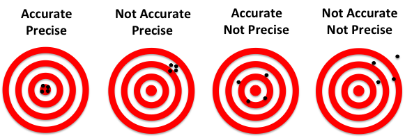

**TipExercise 1. Sample Proportion Distribution.**

**Instructions**

1. Log into the computer station in front of you.
2. Scan the first QR code in the margin to take a quick survey.
3. Open a browser on your computer station and go to https://ckaoxvii.github.io/sample_proportion_distribution/.

[figure not shown]

Survey

**NoteSampling Distribution**

*Recall:* Samples may be used to make inferences about **a population**. Taking repeated samples form a population create a distribution of sample statistics, called the **sampling distribution**.

- The estimator $\hat{p}$ (sample proportion) is **an unbiased estimator**, as long as the samples are random.
- **The precision improves as sample size increases.**
- The shape of the sampling distribution is **more symmetric as sample size increases.**

**NoteCalculating Bias and Standard Error**

Suppose that

1. the samples are randomly chosen from the population, and
2. if the sampling is without replacement, the population is at least 10 times larger than the sample size.

Then

- the bias of $\hat{p}$ is **0**, and
- the standard error (SE) of $\hat{p}$ is given by
  $$SE = \sqrt{\frac{p(1-p)}{n}},$$
  where $p$ is the *population proportion* and $n$ is the *sample size*.

## Section 7.2 Examples

**TipExample 1.**

**Question**

According to the website VGCharts[^1], as of June 2021, PS5 had a total global sales of 9,748,029 units, where as Xbox Series X/S had a total global sales of 5,815,532 units. Use the [webapp](https://ckaoxvii.github.io/sample_proportion_distribution/) from Exercise 1 to complete parts b through e.

1. Find the population proportion, $p$, of PS5, out of the combined total global sales of both consoles.
2. Use the population proportion from part a and a sample size of 10, find the mean of the sampling distribution of the sample proportion $\hat{p}$ after 10 simulations. Is the $\hat{p}$ from each simulation necessarily the same as $p$?
3. Repeat part b and find the mean of the sampling distribution of the sample proportion of $\hat{p}$ after 100 simulated samples.
4. Repeat this simulation using 100 simulated samples, but with a sample size of $n = 50$. What did you notice about the shape of the distribution of $\hat{p}$?
5. Do this one more time but with a sample size of $n = 100$. How is the shape of the distribution of $\hat{p}$ different this time? What is your standard deviation? Calculate the SE by hand and compare.

**Answer**

**Question**

**Answer**

**TipExample 3.**

**Question**

According to a newspaper, 77% of high school seniors have a driver’s license. Suppose we take a random sample of 100 high school seniors and find the proportion who have a driver’s license.

1. What value should we expect for our sample proportion?
2. What is the standard error?
3. How do we interpret these values?
4. Suppose we increase the sample size from 100 to 500. What effect would this have on the standard error?

**Answer**

## Section 7.3. Central Limit Theorem for Sample Proportions

**NoteApplication of the Central Limit Theorem to Sample Proportions**

1. The central limit theorem can be used to estimate proportions in a **population**.
2. The central limit theorem can tell us that, if some basic conditions are met, the sampling distribution of the sample proportion ($\hat{p}$) **will be approximately normal**.

**NoteThe Central Limit Theorem (CLT) for Sample Proportions**

If we take a **random** sample from a population, and if the sample size is **sufficiently large** and the population size **much larger than the sample size**, then the sampling distribution of $\hat{p}$ is approximately **normal** with a mean of **$p$** and a standard deviation of
$$\text{SE} = \sqrt{\frac{p(1-p)}{n}},$$
where $n$ is the sample size.

- If the value of $p$ is unknown, we can use $\hat{p}$ in place of $p$ to estimate the standard error.

**NoteConditions for the Applicability of the CLT for Sample Proportions**

1. **Sampling is random and independent**.
2. **Large sample size**: The sample size $n$, is large enough that the sample expects at least 10 successes and 10 failures. That is,
   $$\begin{align*}
   \text{Number of Successes}: &= np \geqslant 10,\\
   \text{Number of Failures}: &= n(1-p) \geqslant 10.
   \end{align*}$$
3. Large population: If the sampling is done without replacement, the population must be **at least 10 times the sample size**.

**NoteThe Central Limit Theorem and the Empirical Rule**

If the conditions for the central limit theorem are met, the probability that a sample proportion will fall within two standard errors of the population proportion is **approximately 95%**.

## Section 7.4. Estimating the Population Proportion with Confidence Intervals

- Use the central limit theorem to construct a **confidence interval**.

**Note**

We now focus on **inferential statistics**. Often it is easy to calculate statistics from a **sample**, but it is difficult (and sometimes impossible) to calculate parameters from a **population**.

#### Creating a Confidence Interval for Estimating the Population Proportion

**TipExample 7.4.1.**

**Question**

According to pewresearch.org, an October 2016 article indicated that 685 of 1,201 adults randomly surveyed favor the legalization of marijuana.

1. What percent of the adults surveyed supported the requirement to legalize marijuana?
2. Is the value in part (a) a sample statistic or a population parameter?
3. Do you know the percentage of *all* American adults ($p$) that support legalization of marijuana?
4. Do you think the percent of adults surveyed who support the requirement is exactly equal to the percent of all American adults who support legalization? That is, is our sample proportion ($\hat{p}$) exactly equal to the population proportion ($p$)?

**Answer**

a. The percent of adults surveyed who supported legalization is
$$\hat{p} = \frac{685}{1201} \approx 0.5704 \text{ or } 57.04\%.$$
b. The value in part (a) is a sample statistic.
c. No, we do not know the percentage of all American adults ($p$) that support legalization of marijuana.
d. No, we do not think that the sample proportion ($\hat{p}$) is exactly equal to the population proportion ($p$).

From the previous sections, we know the following facts:

- Our estimator, $\hat{p}$, is an **unbiased** estimator of the population proportion, $p$. Therefore, the population parameter, $p$, should be **close to** our sample statistic, $\hat{p}$.
- The standard error is estimated as
  $$\text{SE}_{\text{est}} = \sqrt{\frac{\hat{p}(1-\hat{p})}{n}} = \sqrt{\frac{0.57(1-0.57)}{1201}} \approx 0.0143.$$
- Since the sample size is large, the probability distribution of $\hat{p}$ is approximately **normal** and centered around the true population proportion.
- There is about a 95% chance that $\hat{p}$ is within **two** standard errors of population proportion $p$. Thus,
  $$2 \times \text{SE} = 2 \times 0.0143 = 0.0286.$$
- Therefore, we are 95% confident that the value of the true population proportion is within **2.86** percentage points of **0.57**.
- Hence, we are 95% confident that the true population proportion (i.e., the proportion of *all* American adults who support legalization of marijuana) is between
  $$0.57 - 0.0286 = 0.5414$$
  and
  $$0.57 + 0.0286 = 0.5986.$$
  This is called a **confidence interval**.

**NoteConfidence Interval**

**Confidence intervals** provide us with

1. A range of **possible values** for a population parameter.
2. A confidence level, which express our level of confidence that the interval contains the **true population parameter**.
3. Tells us that how often the estimation is successful.
4. Measure the success rate of the **method**, not of any one particular interval.

**NoteMargin of Error**

The **margin of error** tells us how far from the population parameter our estimate can be.
$$\text{Margin of Error} = z^* \times \text{SE}_{\text{est}},$$
where $z^*$ indicates the number of standard errors to include in the margin of error.

From the empirical rule, we know that

- $z^\ast = 1$ corresponds with an approximate confidence level of **68%**;
- $z^\ast = 2$ corresponds with an approximate confidence level of **95%**;
- $z^\ast = 3$ corresponds with an approximate confidence level of **99.7%**.

**NoteConfidence Level & Margin of Error**

The table below shows the more precise $z^\ast$ values for some frequently used confidence levels.

| Confidence Level | Margin of Error is | $z^\ast$ |
| --- | --- | --- |
| **80%** | **1.282** Standard Errors | **1.282** |
| **90%** | **1.645** Standard Errors | **1.645** |
| **95%** | **1.960** Standard Errors | **1.960** |
| **99%** | **2.576** Standard Errors | **2.576** |
| **99.7%** | **3** Standard Errors | **3** |

**NoteConfidence Interval for a Population Proportion.**

Confidence intervals are of the form:
$$\hat{p} \pm m,$$
where $m$ is the margin of error. Since $m = z^\ast \cdot \text{SE}$, where $\text{SE}$ is the standard error, the confidence interval is
$$\hat{p} \pm z^\ast \cdot \text{SE} \quad \text{or} \quad (\hat{p} - z^\ast \cdot \text{SE}, \; \hat{p} + z^\ast \cdot \text{SE}).$$

To find SE, we substitute $\hat{p}$ for $p$, since $p$ is unknown, and estimate the standard error as
$$\text{SE}_{\text{est}} = \sqrt{\frac{\hat{p}(1-\hat{p})}{n}}.$$

**WarningRemark.**

Since the confidence interval calculations are based on the central limit theorem for sample proportions, the conditions for the CLT must be satisfied to create a confidence interval.

**NoteConditions for the Central Limit Theorem for Sample Proportions**

1. Sampling is random and independent.
2. Large sample: The sample size, 𝑛, is large enough to expect at least 10 successes and 10 failures. That is, $np \geqslant 10$ and $n(1-p) \geqslant 10$.
3. Large population: If the sampling is done without replacement, the population must be at least 10 times larger than the sample size.

## Section 7.4 Examples

**TipExample 1.**

**Question**

1. During a recent semester, 63 of the 159 MAT 223 students randomly surveyed indicated that they had a negative situation occurred to them based on a posting on social media. Let us estimate the percentage of all Flagler College students who had a negative situation occur to them based on a posting on social media.
1. What percent of the students surveyed had a negative situation occur to them based on a posting on social media?
2. What symbol do we use to represent the proportion (percentage) that we calculated in (a)? Is this value a sample statistic or a population parameter?
3. Check the conditions of the central limit theorem to create a confidence interval.
- Is the sample random and independent?
- Is the sample size sufficiently large?
- Is the population sufficiently large?
4. Calculate the standard error.
5. Construct a 95% confidence interval. What is the value of $z^\ast$?
- Calculate the margin of error.
- Find the lower bound of the confidence interval.
- Find the upper bound of the confidence interval.
6. Graph and label the confidence interval.
7. Interpret the confidence interval.

**Answer**

a. The percentage is
$$\hat{p} = \frac{63}{159} \approx 0.396 \text{ or } 39.6\%.$$
b. The symbol we use to represent the proportion calculated in (a) is $\hat{p}$. This value is a sample statistic.
c. Conditions: - Yes, the sample is random and independent. - Yes, the sample size is sufficiently large since $n\hat{p} = 159 \times 0.396 \approx 63 \geqslant 10$ and $n(1-\hat{p}) = 159 \times (1-0.396) \approx 96 \geqslant 10$. - Yes, the population is sufficiently large since the population of Flagler College students is much larger than 10 times the sample size.
d. The standard error is estimated as
$$\text{SE}_{\text{est}} = \sqrt{\frac{\hat{p}(1-\hat{p})}{n}} = \sqrt{\frac{0.396(1-0.396)}{159}} \approx 0.0387.$$
e. To construct a 95% confidence interval, we use $z^\ast = 1.960$.
- The margin of error is
$$m = z^\ast \times \text{SE}_{\text{est}} = 1.960 \times 0.0387 \approx 0.0758.$$
- The lower bound of the confidence interval is
$$\hat{p} - m = 0.396 - 0.0758 \approx 0.3202.$$
- The upper bound of the confidence interval is
$$\hat{p} + m = 0.396 + 0.0758 \approx 0.4718.$$
f.

[figure not shown]

g. We are 95% confident that the true proportion of all Flagler College students who had a negative situation occur to them based on a posting on social media is between approximately 32.02% and 47.18%.

**TipExample 2.**

**Question**

According to pewresearch.org, a 2014 survey found that 32.1% of adults aged 18–34 were living with their parents. Suppose that this was based on a random sample of 1,200 adults in this age group.

1. Check that the conditions for the CLT apply.
2. Use the [app](https://ckaoxvii.github.io/sec_74_confidence_interval_app/) to find the confidence interval using confidence levels of 80%, 90%, 95%, and 99% to estimate the population proportion of all Americans in this age group who live with their parents.
3. What happened to the confidence interval as the level of confidence increases?
4. Is it plausible to conclude that the true percentage of adults in this age group living with parents is 38%?

**Answer**

**ImportantImportant**

As the confidence level increase, the **length** of the confidence interval also increases.

**TipExample 3.**

**Question**

A political consultant randomly surveys 500 voters in a district to see how many intend to vote for a certain candidate. Of the 500 voters surveyed, 265 indicate they will vote for the candidate. Use a 99% confidence interval, should the consultant predict that the candidate will win the election? Why or why not? (He/she must obtain a simple majority of the votes.)

1. Verify the conditions for the CLT.
2. Construct a 99% confidence interval.
3. Summarize your results.

**Answer**

a. The sample is random and independent. Since $n\hat{p} = 500 \times 0.53 = 265 \geqslant 10$ and $n(1-\hat{p}) = 500 \times (1-0.53) = 235 \geqslant 10$, the sample size is sufficiently large. The population is sufficiently large since the population of voters in the district is much larger than 10 times the sample size.
b. To construct a 99% confidence interval, we use $z^\ast = 2.576$. The standard error is estimated as
$$\text{SE}_{\text{est}} = \sqrt{\frac{\hat{p}(1-\hat{p})}{n}} = \sqrt{\frac{0.53(1-0.53)}{500}} \approx 0.0223.$$
The margin of error is
$$m = z^\ast \cdot \text{SE}_{\text{est}} = 2.576 \times 0.0223 \approx 0.0574.$$
The lower bound of the confidence interval is
$$\hat{p} - m = 0.53 - 0.0574 \approx 0.4726.$$
The upper bound of the confidence interval is
$$\hat{p} + m = 0.53 + 0.0574 \approx 0.5874.$$
Thus, the 99% confidence interval is
$$(0.4726, \; 0.5874).$$
c. The consultant should only predict a win if the confidence interval only contains values that are greater than 50%. Since the confidence interval includes values less than 0.5, it is not certain that the candidate will win the election.

**TipExample 4.**

**Question**

According to housingwire.com, 93.8% of homeowners had “positive equity” in their homes. Suppose that the margin of sampling error is $\pm 3$ percentage points with a confidence level of 95%.

1. State the confidence interval in interval notation.
2. How would you interpret this confidence interval?

**Answer**

a. Note that $p = 0.938$ and the margin of error is $m = 0.03$. Thus, the confidence interval is
$$(0.938 - 0.03, 0.938 + 0.03) = (0.908, \; 0.968).$$
b. We are 95% confident that the true proportion of all homeowners who have positive equity in their homes is between 90.8% and 96.8%.

## Section 7.5. Comparing Two Population Proportions with Confidence Intervals

**NoteSample Proportions**

**NoteBasic Approach**

1. Our comparison of two population proportions will be based on the sample statistic: **$\hat{p}_1 - \hat{p}_2$**.
2. This statistic is used to estimate the difference between two population proportions: **$p_1 - p_2$**.
3. Find a confidence interval for the difference in proportions: $p_1 - p_2$.
4. Check whether **0** is included in the confidence interval.
5. Interpreting the confidence interval using the table below:

| Interval | Interpretation |
| --- | --- |
| $(-,+)$ | The interval contains 0, so the population proportions may be equal. |
| $(+,+)$ | The population proportions are different, and $p_1 > p_2$. |
| $(-,-)$ | The population proportions are different, and $p_1 < p_2$. |

**NoteGeneral Method**

The confidence interval for two proportions has the same structure as the confidence interval for one proportion
$$\text{Statistic} \pm z^\ast \times \text{SE}_{\text{est}},$$
where
$$\text{SE}_\text{est} = \sqrt{\frac{\hat{p}_1(1-\hat{p}_1)}{n_1} + \frac{\hat{p}_2(1-\hat{p}_2)}{n_2}}.$$
And $z^\ast$ is chosen to correspond to the desired confidence level, as we did for one proportion. Putting the two equations together, we have
$$(\hat{p}_1 - \hat{p}_2) \pm z^\ast \times \sqrt{\frac{\hat{p}_1(1-\hat{p}_1)}{n_1} + \frac{\hat{p}_2(1-\hat{p}_2)}{n_2}}.$$

**NoteNecessary Conditions for Comparing Two Proportions**

1. Random and independent samples. Both samples are randomly drawn from their respective populations and are independent of each other.
2. Large samples. Both sample sizes are large enough that each sample expects at least 10 successes and 10 failures. That is,
   $$\begin{align*}
   \text{Sample 1:} \quad & n_1\hat{p}_1 \geqslant 10, \quad n_1(1-\hat{p}_1) \geqslant 10, \\
   \text{Sample 2:} \quad & n_2\hat{p}_2 \geqslant 10, \quad n_2(1-\hat{p}_2) \geqslant 10.
   \end{align*}$$
3. Large populations. If the sampling is done without replacement, both populations must be at least 10 times larger than their respective sample sizes.4
4. The two samples are independent of each other.

**TipExample 7.5.1.**

**Question**

A June 2025 poll asking opinions on the GOP’s budget and tax bill was conducted by Pew Research. Pollsters found that 77% of Democrats surveyed believed the bill would hurt middle-income earners, while only 52% of Republicans felt the same way. Suppose that 540 Democrats were surveyed and 537 Republicans were surveyed.

1. Identify the two populations.
2. If we let sample 1 represent the Democrats, what does 540 represent in words and symbols?
3. What does 77% represent in words and symbols?
4. If we let sample 2 represent the Republicans, what does 537 represent in words and symbols?
5. What does 52% represent in words and symbols?
6. Check the conditions for comparing two proportions.
7. How many of those Democrates surveyed believed the bill will hurt middle-income earners?
8. How many of those Republicans surveyed believed the bill will hurt middle-income earners?
9. Use the [webapp](https://ckaoxvii.github.io/sec_75_conf_int_two_pops_app/) to find a 95% confidence interval for the difference in population proportions.
10. Complete the following table.

| Difference | Count 1 | Total 1 | Count 2 | Total 2 | Sample Difference | Standard Error | Lower Limit | Upper Limit |
| --- | --- | --- | --- | --- | --- | --- | --- | --- |

11. Does the confidence interval contain 0?
12. Is there reason to believe that the population proportion of Republicans and Democrats who believe the bill will hurt the middle-class is significantly different?
13. Interpret the confidence interval.

**Answer**

Section 7.5. Examples

**TipExample 1.**

**Question**

According to data published by cdc.gov, a 2012 survey indicated that 1.7% of drivers in Alabama admitted to driving after drinking “too much” alcohol. Similar data indicated that 1.4% of drivers in Georgia admitted to driving after drinking “too much” alcohol. Is there a significant difference in the proportion of drivers who have admitted to driving after drinking between the two states? Suppose each state randomly surveyed 1000 drivers. Construct a 90% confidence interval to answer the question of interest.

1. Identify the populations.
2. Check that the conditions for the CLT apply.
3. Use the [webapp](https://ckaoxvii.github.io/sec_75_conf_int_two_pops_app/) to construct a 90% confidence interval.
4. Complete the table below.

| Difference | Count 1 | Total 1 | Count 2 | Total 2 | Sample Difference | Standard Error | Lower Limit | Upper Limit |
| --- | --- | --- | --- | --- | --- | --- | --- | --- |

5. Interpret this confidence interval.

**Answer**

**TipExample 2.**

**Question**

Extracting natural gas through hydraulic fracturing, or “fracking,” is controversial practice. A Gallup poll conducted in 2015 asked respondents if they favored or opposed fracking. The data was broken down by age groups and found that 32% of 18-29 year olds favored fracking, while 46% of 50-64 year olds favored fracking.

Suppose a 95% confidence interval for the difference in the population proportions is $(–.1998,-.0802)$. Does this interval indicate there is a difference in support of fracking between in these two age groups? Please explain your reasoning.

**Answer**

**TipExample 3.**

**Question**

Suppose that a study to determine which of two treatments for severe arthritis, medications or surgery, was better. Patients were randomly assigned to receive either medication or surgery. 200 patients received medication, and at the end of the study, 120 of them were in remission (a good outcome). 170 patients received surgery, and at the end of the study, 75 were in remission.

Let $p_1$ represent the proportion of patients who would be in remission if they took medication and let $p_2$ represent the proportion who would be in remission if they had surgery A 95% confidence interval for the difference in sample proportions ia 0.06 and 0.26.

Assume that conditions 2, 3, and 4 are satisfied. Interpret the confidence interval. Is one treatment better than the other?

**Answer**

**TipExample 4.**

**Question**

A poll asked a sample of US adults if they felt that the use of AI would increased the gap between the rich and poor in the US. Of those surveyed, 69% ages 18-35 agreed with this statement. Only 60% of those ages 36-50 agreed with this statement. A 95% confidence interval for the difference in the population proportions $p_1 - p_2$ who agree with the statement is $(0.034, 0.146)$. What does this interval tell you about the proportion of adults in these age groups who agree with this statement? Suppose $p_1$ is ages 18–35 and $p_2$ is ages 36–50.

**Answer**

## Footnotes

[^1]: https://www.vgchartz.com/article/449843/ps5-vs-xbox-series-xs-sales-comparison-june-2021/